# Trabajo aplicativo integrador

Enero 2023

[figure not shown]

## Información general

El presente trabajo tiene como autores a:

- Hinojosa Cahuana, Percy Alberth
- Huanca Martinez, Jorge Alberto
- Huancaya Idone, Cesar Dante
- Tintaya Orihuela, Meir Alvaro

## 1. Introducción

### Contexto

En los últimos años, los avances en Big Data y Cloud Computing son señalados en diversos artículos científicos. La velocidad de generación de datos, así como su difusión, sigue en aumento debido a la proliferación de dispositivos móviles, sensores conectados a Internet, y diversas plataformas en la nube (Hernández et al., 2021; Yang et al, 2017). Este paradigma de Big Data proporciona oportunidades para permitir y mejorar la investigación en aplicaciones de soporte de decisiones con un valor sin precedentes para el mundo digital, aplicaciones que incluyen negocios, ciencias e ingeniería. Esta tendencia es compartida también por el sector público (Hernández et al., 2021; Munné, 2016).

Se ha encontrado información de que los gobiernos recopilan y generan inmensas cantidades de datos mediante sus actividades cotidianas, tales como la gestión de pensiones, la recolección de impuestos, los registros en los sistemas nacionales de salud, el registro de datos de transporte y tráfico, y la emisión de documentos oficiales (Munné, 2016). En ese sentido, el sector educación va acumulando inmensa cantidad de data, como muestra de ello se puede observar diversas bases de datos: Censo Educativo, Patrón DRE/UGEL, ENDO, ENDI, SIAGIE, Semáforo Escuela, entre otros. Así, el sector educación deja en claro el valor de la Big Data para la elaboración de políticas públicas y toma de decisiones de funcionarios con el fin de mejorar las condiciones de la comunidad educativa: estudiantes, familias, gestores regionales, directores y docentes (Ministerio de Educación del Perú, s.f.).

### Problema

Ante la ingente cantidad de datos en el sector educación, los gobiernos tanto a nivel nacional como internacional buscan estrategias para analizar y visualizar los datos de los distintos actores de la comunidad educativa (Alvtz & Quinteros, 2022; Miranda & Delgado, 2018; Rodríguez et al., 2016). Si bien se prioriza la analítica de los estudiantes en Educación Básica Regular, la información sobre docentes no ha recibido el mismo volumen de análisis para la visualización de datos (Ministerios de Educación del Perú, 2017). Mucho menos, la analítica de indicadores de salud mental que afecta su rol formativo y bienestar.

### Estrategia de visualización de datos

En ese sentido, resulta importante explicar el potencial de la librería ggplot2 en este contexto, el cual es un paquete de visualización de datos ampliamente utilizado debido a sus poderosas capacidades y flexibilidad (Wickham, 2016). Entre los beneficios de ggplot2 para las organizaciones del sector público, se puede destacar su capacidad para explorar y comprender los datos, para crear y usar visualizaciones que permitan respaldar la toma de decisiones de las autoridades, para personalizar gráficos acorde a las necesidades específicas, y brindar visualizaciones informativas y comprensibles a los ciudadanos (Munné, 2016; Orrego et al., 2022).

Por todo lo anterior, resulta importante desarrollar proyectos que permitan visualizar la información de datos abiertos en el sector educación, específicamente sobre la salud mental de los docentes.

### Objetivo

El presente trabajo persigue el siguiente objetivo:

> > Utilizar funciones para visualizar la evolución de problemas de salud mental en docentes de Educación Básica Regular durante el periodo 2014-2021 según sexo, área y nivel educativo, a partir de los resultados de la Encuesta Nacional de Docentes (ENDO).

## 2. Metodología

### Base de datos

- **Fuente:** Portal Web ESCALE (Estadística de la Calidad Educativa).
- **Archivo:** “H: ENDO” / BD_SPSS.zip
- **Enlace:** [ESCALE_MINEDU](http://escale.minedu.gob.pe/uee/-/document_library_display/GMv7/view/4385260)

### Variables

- **Denominación:** Durante el presente año usted, ¿sufrió o sufre alguna de las siguientes enfermedades o malestares? (Respuesta múltiple)
- **Categorías:** “Estrés”, “Depresión”, “Ansiedad”, etc.

##### Nota

- La categoría “ansiedad” se incluyó desde la medición de 2018
- La formulación de la pregunta varió entre las diferentes mediciones:

  | Año | Formulación |
  | --- | --- |
  | 2014 | “durante los últimos dos años…” |
  | 2016-2018 | “durante el año pasado…” |
  | 2020-2021 | “durante el presente año…” |

### Pre-procesamiento

Se aplicó el factor de expansión a la prevalencia de los problemas de salud mental. Asimismo, se realizó un cruce con variables socio-demográficas (Sexo, Área geográfica, Nivel Educativo) para ver la prevalencia según cada una de las categorías.

Para dicho análisis se utilizó principalmente el paquete **pollster**, el cual permite realizar tablas simples y cruzadas con los datos ponderados.

Mayor detalle en nuestro [repositorio Github](https://github.com/jorgehmartinez/PracticeGroup_R/blob/main/trabajo_aplicativo_integrador/procesamiento_data/preprocesamiento_endo.R)

### Procesamiento

#### Variables identificadas:

La data procesada se encuentra en [nuestro repositorio](https://github.com/jorgehmartinez/PracticeGroup_R/blob/main/trabajo_aplicativo_integrador/evolucion_prevalencia_salud.csv), contiene las siguientes cuatro variables:

| Variable | Descripción | Valores |
| --- | --- | --- |
| variable | nombre del problema de salud mental | Estrés, Depresión, Ansiedad |
| segmento | grupo de docentes evaluados | General Hombres, Mujeres, Urbano, Rural, Inicial, Primaria, Secundaria |
| valor | prevalencia, en porcentaje, del problema de salud mental | Rango: 4.01 a 65.20 |
| year | año en que se realizó la medición | Rango: 2014 a 2021 |

#### Análisis propuesto:

De manera específica, se resalta el uso de funciones del paquete **ggplot2** como: a) **geom_line**, que permite graficar la evolución de un indicador a partir de una variable numérica y personalizar el gráfico según características como color, tamaño, tipo de línea, etc.; b) **facet_wrap**, que es utilizado para agrupar gráficos según las categorías de un una variable cualitativa; y c) **scale_x_continuos** o **scale_y_continuos**, que permiten mejorar la visualización y estética con que se presentan los ejes del gráfico, por ejemplo: i) mostrar sus valores en porcentaje, ii) establecer sus limites, iii) personalizar sus etiquetas.

Además de ggplot2, existen otros paquetes complementarios como: **ggrepel** para evitar que etiquetas no se superpongan (Slowikowski, 2022); **scales** para automatizar la detección de etiquetas y puntos de corte (Wickham & Seidel, 2022); y **hbrthemes** para elegir temas adaptados a una tipografía específica (Rudis, 2020).

## 3. Resultados

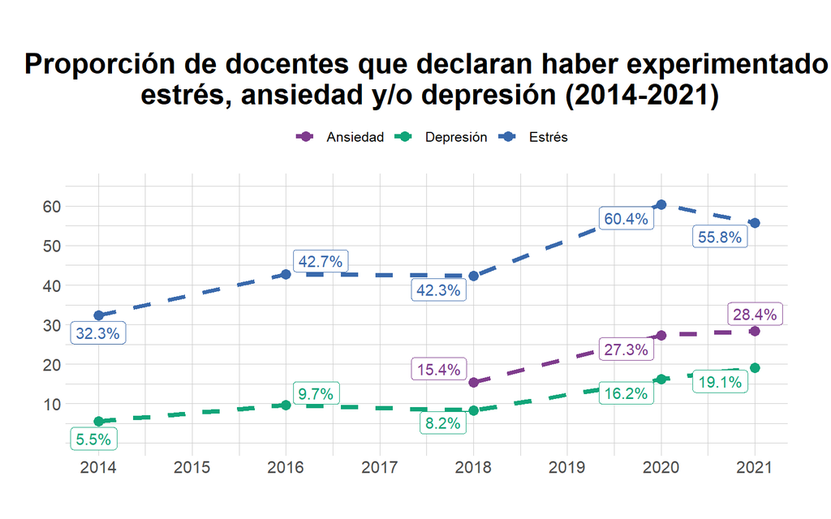

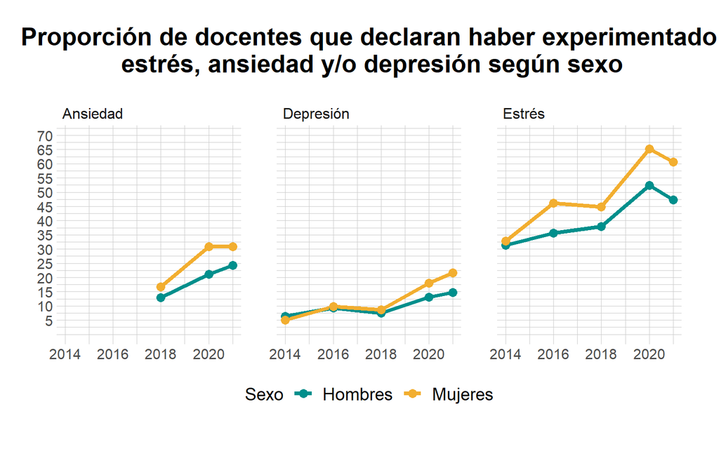

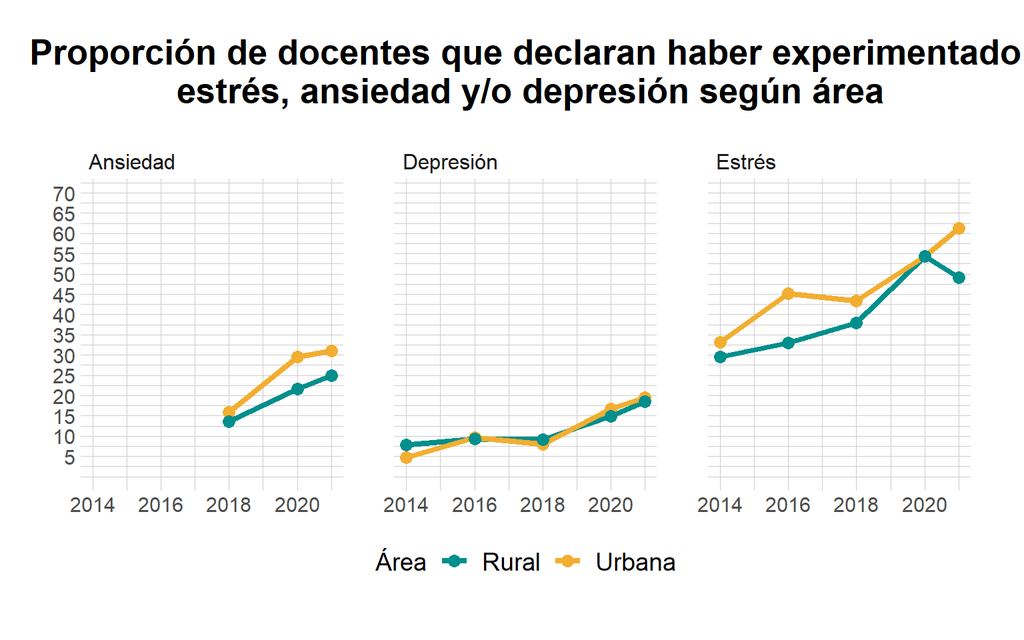

[figure not shown]

## 4. Discusión

A continuación, se discutirá la utilidad de los argumentos y funciones de los paquetes R usados para la visualización de datos. Considerando la ingente cantidad de bases de datos recopilado por el Ministerio de Educación del Perú, se identifica que la función **ggplot2::geom_line** permite ver la frecuencia de datos en función a otra variable continua, en caso de la base analizada, se evidencia la utilidad para identificar patrones de cantidades continuas, tal como se evidencia en investigaciones similares (Sustaita, 2017).

En el caso de la presente investigación, esta función **ggplot2::geom_line()** permite visualizar una serie de tiempo y puntuaciones sobre sintomatología de problemas de salud mental. De manera específica, el argumento **aes** no solo ayuda a definir las variables para la creación del gráfico, sino a delimitar otros atributos estéticos, como el tamaño y diseño de la línea. También, se evidencia que el argumento **labs** permite asignar un nombre ilustrativo en los gráficos. Por ello, los algoritmos descritos en **aes** como **labs** mejoran la claridad visual de datos abiertos masivos, sobre todo resulta útil para funcionarios o especialistas involucrados en la toma de decisiones en políticas públicas (Munné, 2016; Rodríguez et al., 2016).

En esa misma línea de la estética y claridad visual, el gráfico 1 demuestra la utilidad de los paquetes **hrbrthemes** y **ggrepel** para complementar la forma en que se visualizan los datos. Se evidencia que la función **hrbrtheme::theme_ipsum()** ayuda a definir una tipografía amigable, asimismo, la función **ggrepel::geom_label_repel** evitó el traslape de la coordenada con la etiqueta que representa dicha coordenada (Slowikowski, 2022). Por ejemplo, como se aprecia en el gráfico 1, el punto de la coordenada entre el porcentaje de estrés y el año 2014 no se traslapa con la etiqueta del porcentaje de docentes con estrés (32.3%).

Otro punto de mejora de la visualización de datos consiste en el formato y rango de valores en el eje X y eje Y. Como se observan en los cuatro gráficos, se mejora el formato del gráfico a partir algoritmos que manipulan el diseño del color. Así, el algoritmo basado en la función **scale_colour_manual()** de ggplot2 y la función **carto_pal()** del paquete complementario rcartocolor (Nowosad, 2018; Wickham, 2016) establecen argumentos para ampliar la paleta de colores, así como especificar un grupo de colores. Además, la función **scale_+_continuous** permite delimitar el valor de inicio y fin de los ejes del gráfico, así como definir la constante de salto en cada eje.

En caso de la visualización de los rangos de valores, se demuestra la importancia de las funciones del paquete **scales**, pues facilita la transformación y escalamiento de los valores de la data (Wickham & Seidel, 2022). De hecho, para la presente investigación, se implementó el escalamiento de variables continuas, tal como las puntuaciones de sintomatología convertidas a porcentaje.

A parte de las mejoras en el color, tamaño y ejes de abscisas y ordenadas en los gráficos, el algoritmo responde adecuadamente para la personalización de los títulos, fondo y leyenda de los gráficos. Gracias a la función **ggplot2::theme**, se genera indicaciones claras para modificar tamaño, fuente y estilo de los elementos textuales de los gráficos (ver gráfico 1, 2, 3 y 4), así como modificar la posición de la leyenda. En ese sentido, la función ofrece una amplia serie de argumentos para editar libremente componentes no relacionados con la data del gráfico, maximizando la personalización del gráfico (Wickham, 2016).

## 5. Conclusiones

En este estudio se evaluó la utilidad de los algoritmos para la visualización de datos y evolución de problemas de salud a partir de los datos abiertos del Ministerio de Educación del Perú. Se utilizó una combinación de funciones procedentes de los paquetes principales ggplot2 y dplyr, así como de paquetes complementarios ggrepel, scales, hrbrthemes y rcartocolor. El desarrollo del algoritmo se enfoca no solo en la identificación de gráficos útiles para el análisis y lectura de la información de las bases de datos abiertos, sino en la claridad, entendimiento y estética visual del gráfico.

Se concluye que:

- El algoritmo es efectivo en términos de sustraer, manipular y graficar la data procedente del ESCALE Minedu, específicamente de la Encuesta Nacional de Docentes (ENDO)
- El algoritmo resulta útil para visualizar la data según el segmento de preferencia, por lo que puede contribuir a un análisis más rápido y certero para autoridades o especialistas en la toma de decisiones sobre políticas públicas en el sector educación.
- A futuro resultaría importante desarrollar algoritmos enfocados en la dinámica y animación

## 6. Bibliografía

- Alvtz-Meza, A., & Quinteros, E. (2022). Proyecto Aplicado en Ciencia de Datos: Visualización y Análisis de Datos del Ministerio de Educación de Colombia. doi: 10.13140/RG.2.2.20818.02249
- Rudis, B. (2020). hrbrthemes: Additional Themes, Theme Components and Utilities for ‘ggplot2’. http://github.com/hrbrmstr/hrbrthemes
- Hernández Sánchez, J., Álvarez Aros, E. L., & Cantón Croda, R. M. (2021). Tendencias del big data y cloud computing: Bibliometría del 2010 al 2020. Ciencia Latina Revista Científica Multidisciplinar, 5(4), 3999-4016.
- Li, J., Huang, L., Zhou, Y., He, S., & Ming, Z. (2017). Computation Partitioning for Mobile Cloud Computing in a Big Data Environment. IEEE Transactions on Industrial Informatics, 13(4), 2009-2018.
- Munné, R. (2016). Big Data in the Public Sector. In: Cavanillas, J., Curry, E., Wahlster, W. (eds.) New Horizons for a Data-Driven Economy. Springer, Cham.
- Ministerio de Educación del Perú (s.f.). Estadística de la Calidad Educativa.
- Ministerio de Educación del Perú (2017). Perú ¿Cómo vamos en educación?
- Miranda, G.A., & Delgado, Z.Y. (2018) Visualización de indicadores de actividad docente en educación en línea como apoyo a la evaluación formativa. Hamut´ay, 5 (2), 78-93
- Nowosad, J. (2018). ‘CARTOColors’ Palettes. R package version 2.1.0. https://nowosad.github.io/rcartocolor
- Orrego, D., Ugalde, J., Salas, R., Torres, R. & López-Gonzales, J.L. (2022). Visual Predictive Data Analysis Approach for the Academic Performance of Students from a Peruvian University. Applied Sciences, 12.
- Rodríguez, P., Suchan, K., Truflello, R., & Varela, F.(2016). Apoyando la formulación de políticas públicas y toma de decisiones en educación utilizando técnicas de análisis de datos masivos: el caso de Chile. Research Gate. http://dx.doi.org/10.13140/RG.2.1.1419.9283
- Slowikowski K (2022). ggrepel: Automatically Position Non-Overlapping Text Labels with ‘ggplot2’. R package version 0.9.2. https://github.com/slowkow/ggrepel
- Sustaita, L. A. (2017). Visualización de datos a partir de patrones de despliegue en lenguaje de programación R [Tesis de Maestría]. Centro de Investigación en Matemáticas - CIMAT
- Wickham, H. (2016). ggplot2 Elegant Graphics for Data Analysis. New York: Springer.
- Wickham H, & Seidel, D. (2022). scales: Scale Functions for Visualization. https://scales.r-lib.org. https://github.com/r-lib/scales.